# Assignment 2 (due on 10/27)

# 学生：翟君伟 (12132022)，Github: Ckikily

# 得分：42/50

## 1. Significant earthquakes since 2150 B.C.

### 1.1

```python
import pandas as pd
filepath = "earthquakes-2021-10-17_10-20-59_+0800.tsv"
data = pd.read_csv(filepath, sep='\t')
data = data.iloc[1:]

#q1
death_data = data[["Country","Deaths"]]
death_sum_by_country= death_data.groupby("Country").sum()
death_sum_by_country.sort_values(by=["Deaths"],ascending=False,inplace=True)
print(death_sum_by_country.head(10))
```

```
               Deaths
Country
CHINA       2074900.0
TURKEY      1074769.0
IRAN        1011437.0
SYRIA        439224.0
ITALY        434863.0
HAITI        323472.0
AZERBAIJAN   317219.0
JAPAN        278138.0
ARMENIA      191890.0
PAKISTAN     148783.0
```

### 1.2

```python
#q2
mag_of_year = data[["Year","Mag"]]
mag_of_year_count = mag_of_year[mag_of_year["Mag"] > 6 ].groupby(by = ['Year']).count()
print(mag_of_year_count)
```

```
         Mag
Year
-2150.0    1
-2000.0    1
-1250.0    1
-1050.0    1
-479.0     1
...      ...
 2017.0   32
 2018.0   28
 2019.0   27
 2020.0   15
 2021.0   18

[530 rows x 1 columns]
```

### 需要以图像方式展现结果

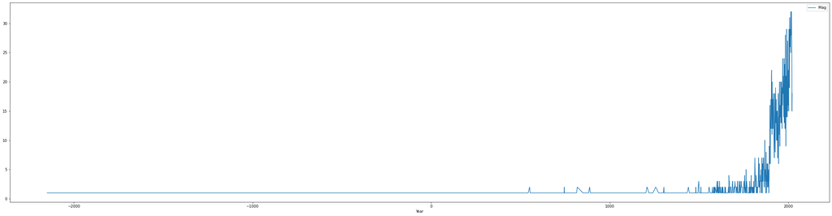

```python
mag_of_year_count.plot(figsize=(40,10))
```

### 1.3

```python
#q3
def CountEq_LargestEq(Country):
    data = pd.read_csv(filepath, sep='\t')
    data = data.iloc[1:]
    mag_of_country =data[data["Country"] == Country]
    count = mag_of_country["Mag"].count()

    max_data = mag_of_country[mag_of_country["Mag"] == mag_of_country["Mag"].max()]
    date = max_data[["Year","Mo","Dy"]]
    return count,date
count,date =CountEq_LargestEq("CHINA")
print(count)

print(date)
```

```
579
       Year   Mo    Dy
973  1668.0  7.0  25.0
```

## 第一题代码运行正常，可以输出正确结果，报告中也展示了部分内容，也针对问题给出部分文字分析，但是：

### 3、第三小题中需要针对`Apply CountEq_LargestEq to every country in the file, report your results in a descending order`，给出多个国家的排序结果。

## 得分：20/25

# ----------------------------------------------------

## 2. Wind speed in Shenzhen during the past 10 years

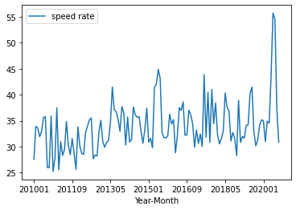

```python
import pandas as pd
import numpy as np
from matplotlib import pyplot as plt
%matplotlib inline

df = pd.read_csv("2281305.csv")
df['direction angle'] = df['WND'].apply(lambda x: x.split(',')[0])
df[' direction quality code'] = df['WND'].apply(lambda x: x.split(',')[1])
df[' type code'] = df['WND'].apply(lambda x: x.split(',')[2])
df['speed rate'] = df['WND'].apply(lambda x: x.split(',')[3]).astype(int)
df['speed quality code'] = df['WND'].apply(lambda x: x.split(',')[4]).astype(int)

df['Year-Month'] = df['DATE'].apply(lambda x: x.split('-')[0]+x.split('-')[1])
a = df.loc[df['speed quality code'] < 2].groupby('Year-Month')['speed rate'].count()
b = df.loc[df['speed quality code'] < 2].groupby('Year-Month')['speed rate'].sum()
df2 = (b/a)
df2 = pd.DataFrame(df2)
df2
df2.plot()
```

## 第二题代码运行正常，可以输出正确结果，报告中也给出了获取风速信息的过程和思路，但是建议在画图的时候，在横纵坐标中表明数据单位。

## 得分：10/10

# ----------------------------------------------------

## 3. Explore a data set

```python
import pandas as pd
import numpy as np
from matplotlib import pyplot as plt
%matplotlib inline

met = pd.read_csv("Marine_CSV_sample.csv")
met= met[['Time of Observation','Sea Level Pressure','Air Temperature','Wind Speed']].dropna(axis=0)
met
met.head()
```

|  | Time of Observation | Sea Level Pressure | Air Temperature | Wind Speed |
| --- | --- | --- | --- | --- |
| 0 | 2015-01-12T00:00:00 | 29.83 | 70.5 | 139 |
| 1 | 2015-01-12T12:00:00 | 29.93 | 66.2 | 165 |
| 2 | 2015-01-12T18:00:00 | 30.02 | 61.2 | 154 |
| 3 | 2015-01-13T06:00:00 | 30.14 | 64.6 | 118 |
| 4 | 2015-01-13T12:00:00 | 30.12 | 66.7 | 123 |

```python
#查找最大海平面气压
number1 = met['Sea Level Pressure'].max()
number1
```

```
'30.14'
```

```python
#查找海平面气压大于10并且大气温度小于70的数组
met2 = met.loc[ (met['Sea Level Pressure'] >10) & (met['Air Temperature'] <70)]
met2
```

[output not shown]

```python
#查找大气温度最大值
number2 =met['Air Temperature'].max()
number2
```

```
'87.8'
```

```python
#查找风速最大值
number3 =  met['Wind Speed'].max()
number3
```

```
463
```

```python
#计算风速的总和
number4 = met['Wind Speed'].sum()
number4
```

```
5959
```

```python
met['Sea Level Pressure'].values
```

```
array(['29.83', '29.93', '30.02', '30.14', '30.12', '30.08', '30.01',
       '29.98', '29.91', '29.88', '29.75', '29.66', '29.54', '29.59', ' ',
       '29.53', '29.97', '30.06', '30.05', '30.08', '30.03', '30.06',
       '30.03', '30.06', '30.00', '30.01', '29.96', '29.95', '29.87',
       '29.79', '29.84', '29.83', '29.88', '29.85', '29.88', '29.82',
       '29.87', '29.81', '29.83', '29.75', '29.82', '29.76', '29.78',
       '29.84', '29.78', '29.86', '29.82', '29.83', '29.87', '29.91',
       '29.86', '29.90', '29.85', '29.87', '29.80'], dtype=object)
```

## 第三题有部分代码无法正常运行，原因出在没有将string转换成float，string是无法用来比较的，在报告中也没有展示出结果。

## 请务必将代码进行完整测试之后再上传！我相信你如果运行过这个程序，你是能看到bug的，如果不知道如何解决这个问题，你可以在提交作业前联系我，我们可以一起讨论。

## 得分 12/15

# ----------------------------------------------------